# Econometrics Methods Project: Figures

Mason Veileux

20/1/2022

This file provides summary statistics and figures related to the data and regression analysis for the Econometrics Methods project.

## Summary Statistics

These are distributions broken down by gender

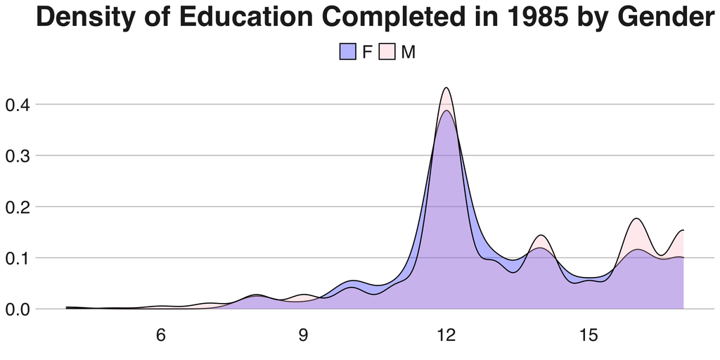

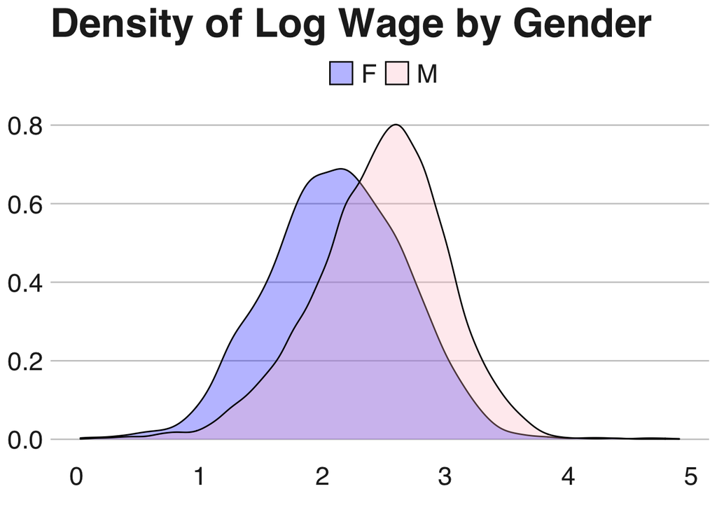

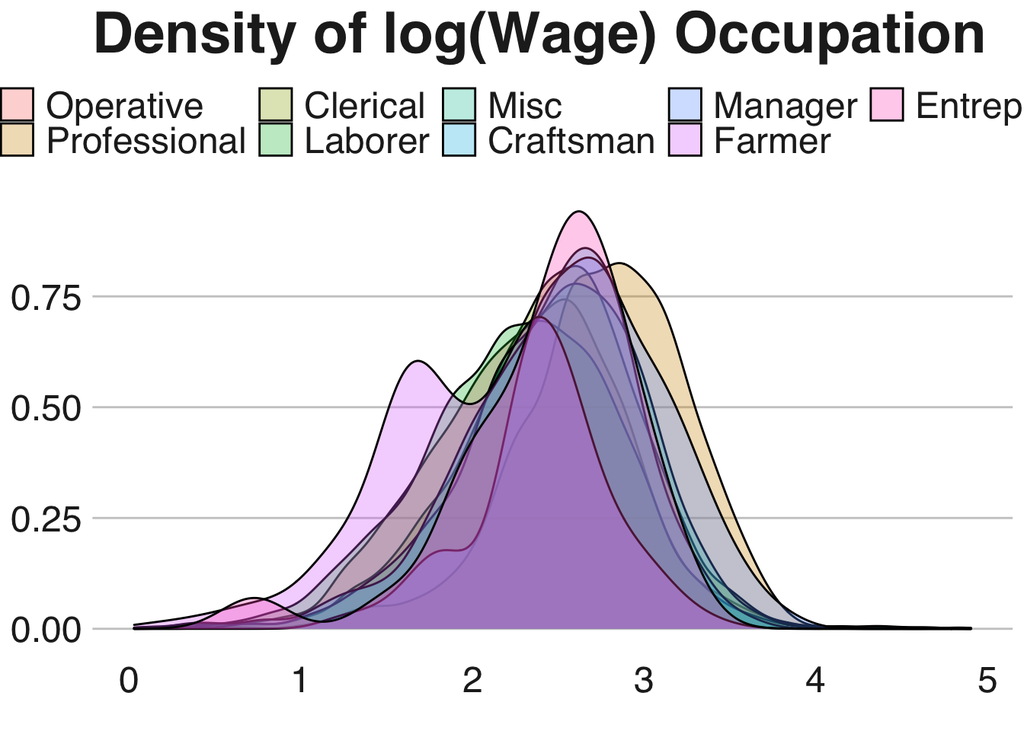

Clearly, men are over-represented in this sample

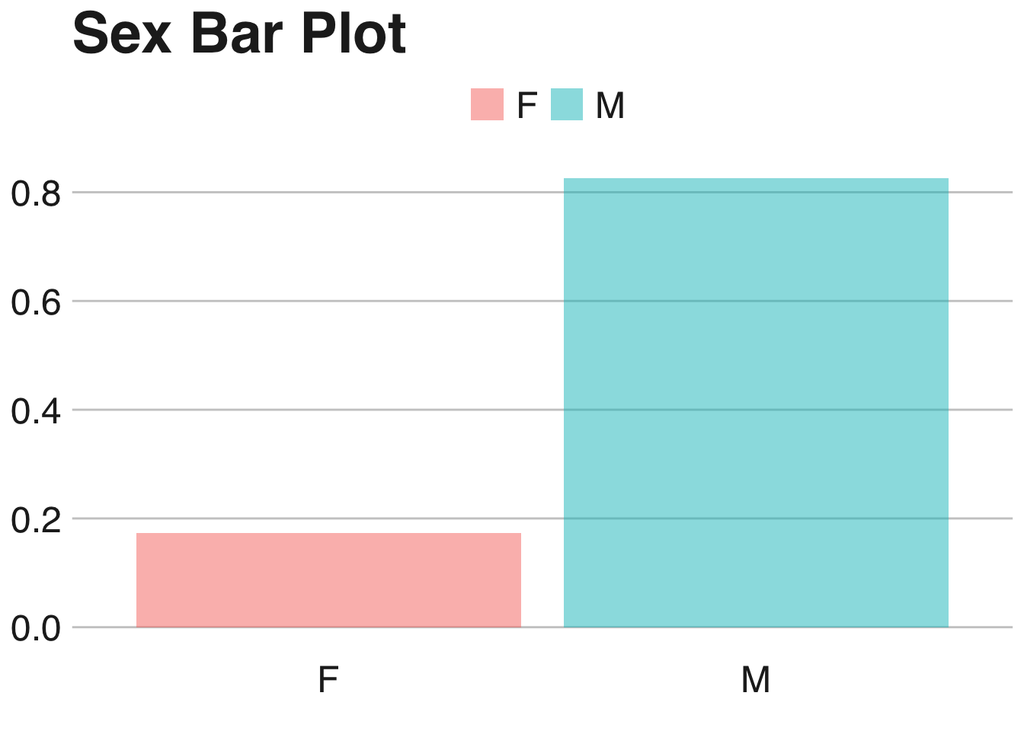

This distribution of white and African-Americans looks similar to the population during this time (1981-1990). Hispanics and Asians are greatly under-represented maybe because the majority of immigration of these groups happened after the PSID began. I believe there is a Latino sample attached to the PSID but did not seem important given the nature of the project.

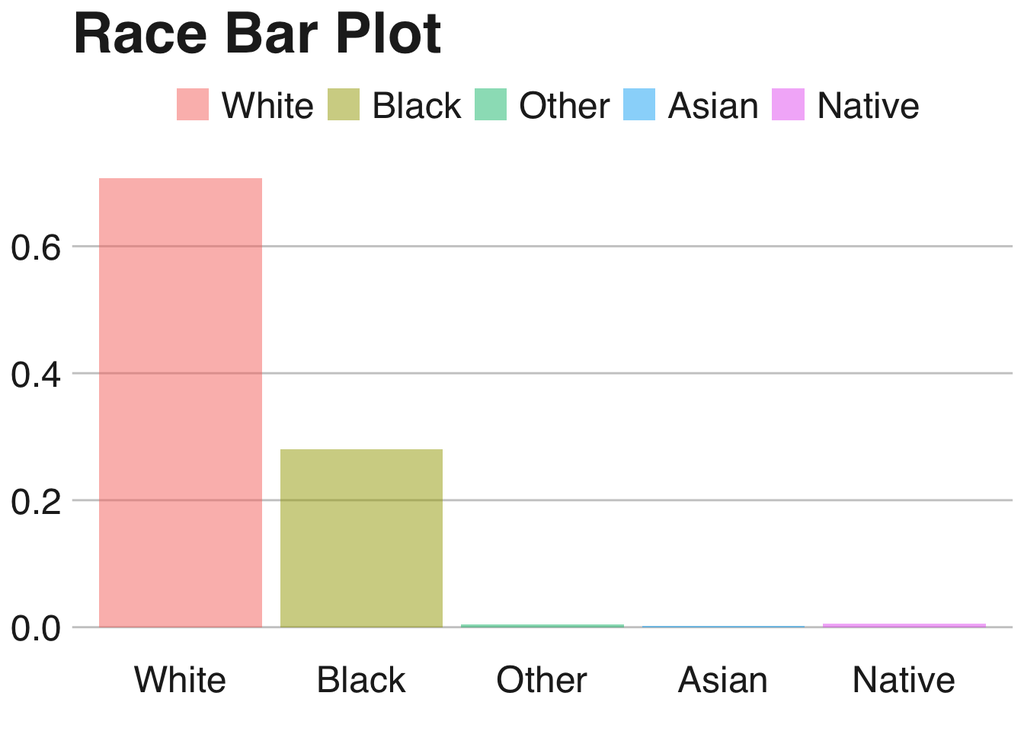

U is for Unemployed, W is for Working. Most people in the sample were working at one time or another.

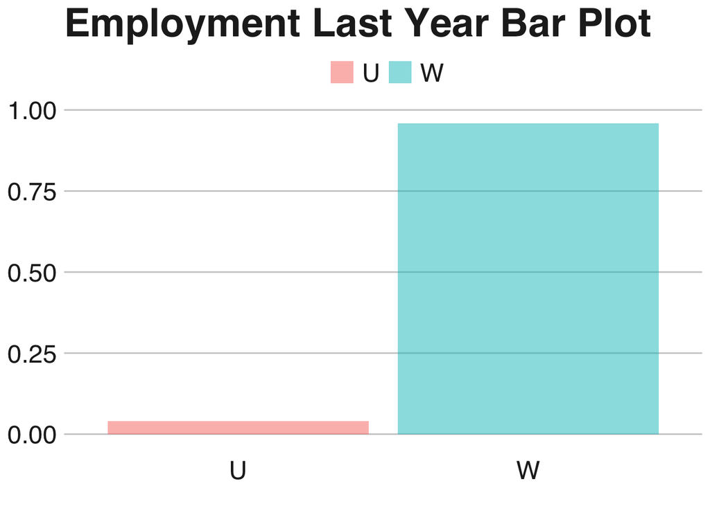

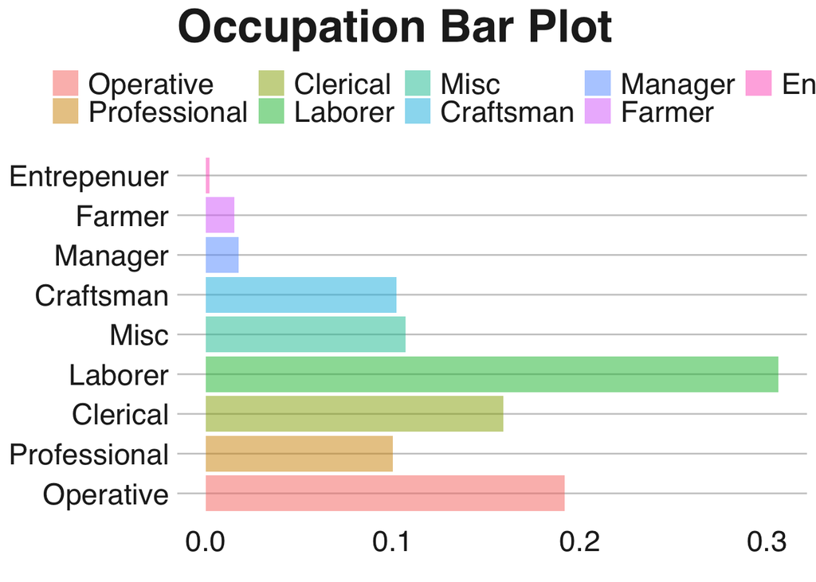

DK means ‘Don’t Know’ if wages are covered by union. There is a 9 in there meaning I did not account for this when cleaning. I am writing this at the end of my paper and cleaning the regression table so I do not wish to go back and clean this up. Doubt it is consequential.

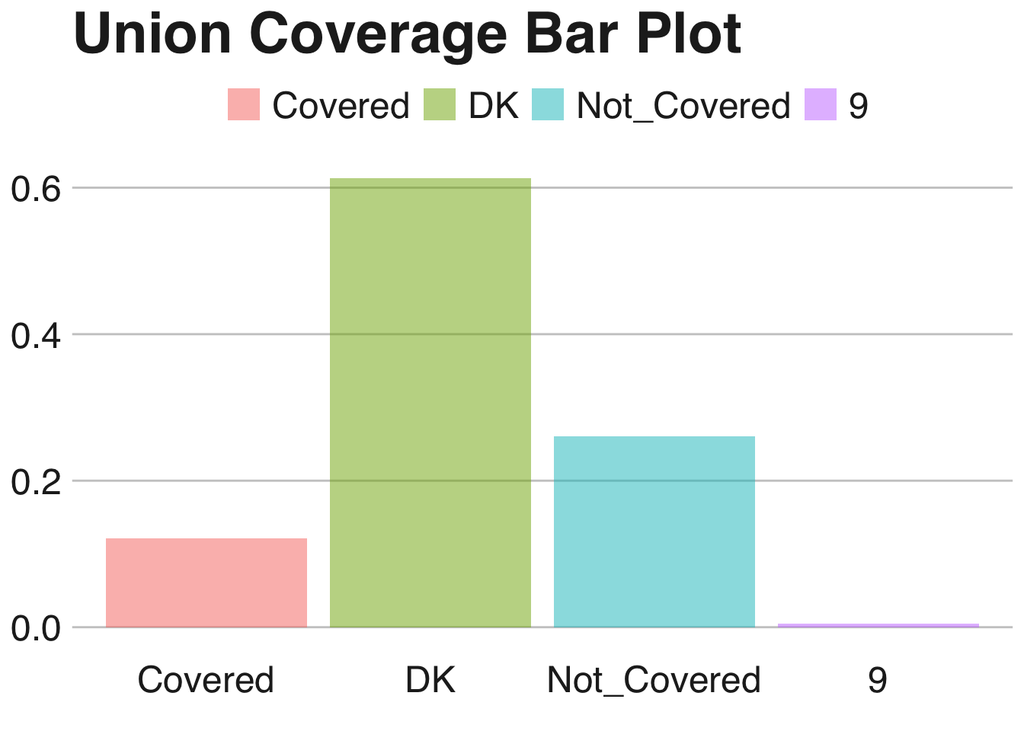

Most individuals are married over time.

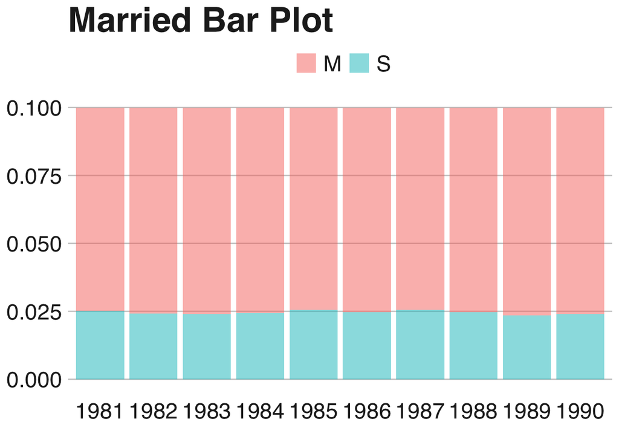

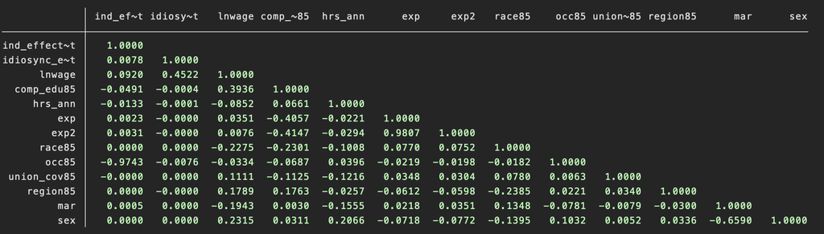

Correlations

This is the output using the ‘cor’ command in Stata

## Regression Statistics

This is additional EDA from the Hausman Taylor regression. I made the individual effects error term a vector then categorized the residuals by occupation. What I think this shows is the distribution of ability within and between occupations. We see that professionals have a high level of ability while farmers, managers, and craftsman have lower levels. There are so few entrepreneurs in the survey that we should disregard this interpretation.

Lastly, note the differences in the tails between groups. Laborers have a long tail on both sides while groups with higher mean ability have long left-tails (and vice versa for those with lower mean ability).

0 is the mean ability of the sample.

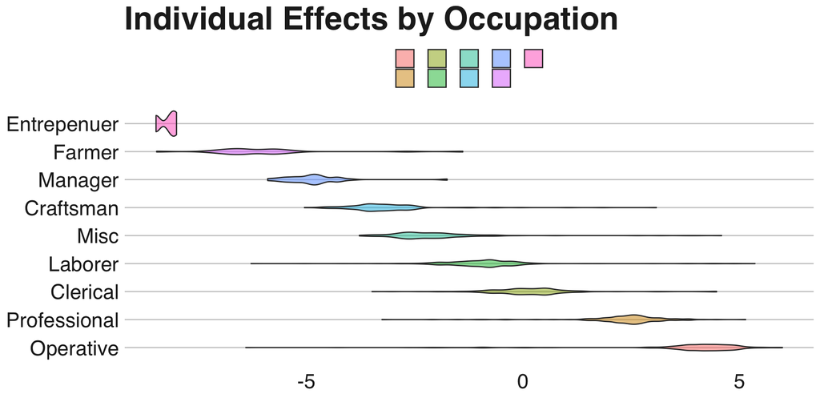

This plot shows the correlations and distributions of the continuous variables in the analysis. The density is reports the variables in the columns. The row values are on the y-axis. u_it is the idiosyncratic error term and alpha_i is the individual error term.

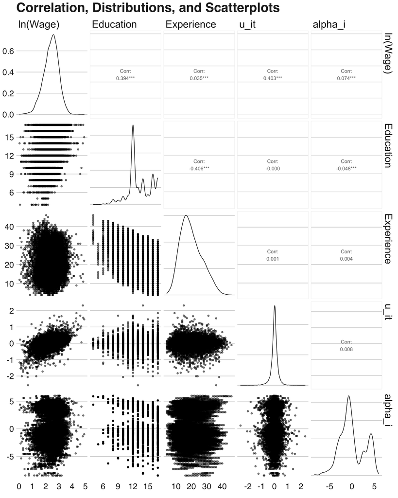